# Exploratory Data Analysis

Tan Mengting

2020/10/9

# Finding #1

## Discover insights of age distribution, relationship with crdit and mean balance

```r
group_by(bank, age) %>%
  summarise(count = n(),
            balance_mean = mean(balance),
            default_count = sum(ifelse(default == "no", 0, 1)),
            subscription_count = sum(ifelse(y == "no", 0, 1)),
            "default_rate(%)" = default_count/count*100,
            "subscription_rate(%)" = subscription_count/count*100) %>%
  arrange(age) -> res
## `summarise()` ungrouping output (override with `.groups` argument)
res
```

```
## # A tibble: 67 x 7
##      age count balance_mean default_count subscription_co~ `default_rate(%~
##    <int> <int>        <dbl>         <dbl>            <dbl>            <dbl>
##  1    19     4         394.             0                2            0
##  2    20     3         661.             0                1            0
##  3    21     7        1774.             0                1            0
##  4    22     9        1455.             0                3            0
##  5    23    20        2118.             1                2            5
##  6    24    24         635.             1                4            4.17
##  7    25    44        1240.             1               10            2.27
##  8    26    77         789.             3                7            3.90
##  9    27    94         852.             4               14            4.26
## 10    28   103        1025.             1               16            0.971
## # ... with 57 more rows, and 1 more variable: `subscription_rate(%)` <dbl>
```

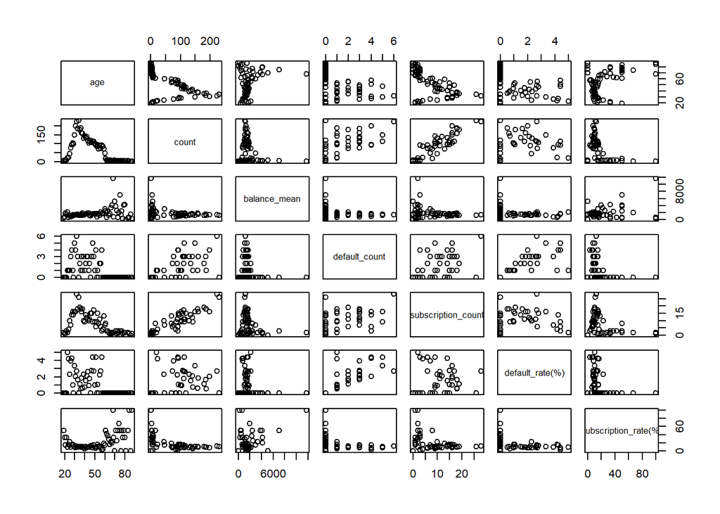

```r
res %>% plot
```

# Finding #2

## Discover insights of job and age

- Only students and retired people have obvious age bias.

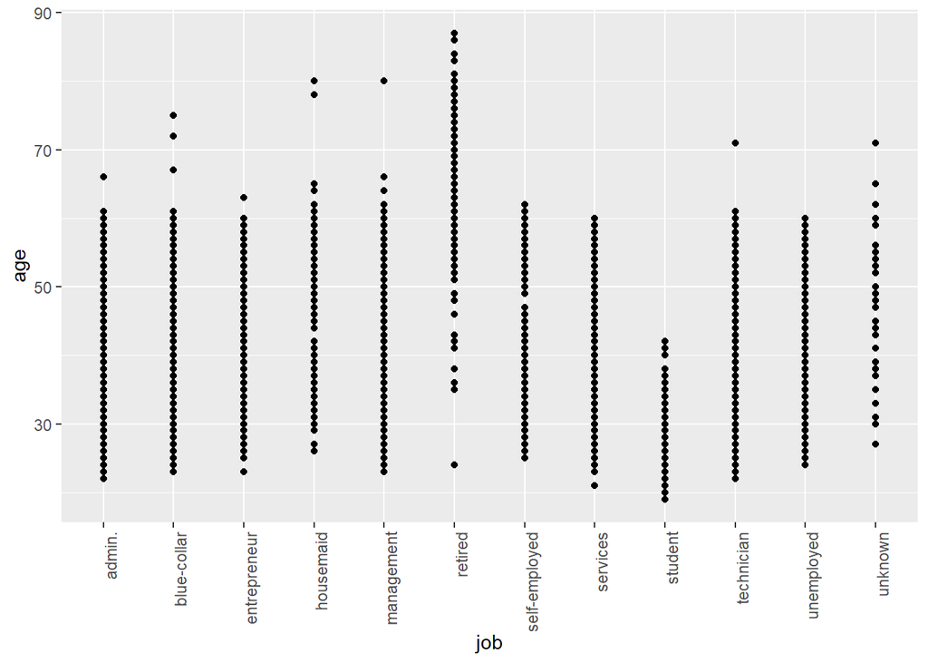

```r
ggplot(bank, aes(job, age)) +
  geom_point() +
  theme(axis.text.x = element_text(angle=90, hjust=1))
```

# Finding #3

## Discover insights of job distribution, relationship with balance mean, default rate and subscription rate

- Many more people take blue0collar and management work.
- Retired people have highest mean balance.
- Blue-collar, unemployed and services people have lowest mean balance.

```r
group_by(bank, job) %>%
  summarise(count = n(),
            balance_mean = mean(balance),
            default_count = sum(ifelse(default == "no", 0, 1)),
            subscription_count = sum(ifelse(y == "no", 0, 1)),
            "default_rate(%)" = round(default_count/count*100,2),
            "subscription_rate(%)" = round(subscription_count/count*100,2)) %>%
  arrange(job) -> res
## `summarise()` ungrouping output (override with `.groups` argument)
res
```

```
## # A tibble: 12 x 7
##    job   count balance_mean default_count subscription_co~ `default_rate(%~
##    <fct> <int>        <dbl>         <dbl>            <dbl>            <dbl>
##  1 admi~   478        1227.             6               58             1.26
##  2 blue~   946        1085.            14               69             1.48
##  3 entr~   168        1645.             7               15             4.17
##  4 hous~   112        2084.             2               14             1.79
##  5 mana~   969        1767.            14              131             1.44
##  6 reti~   230        2319.             3               54             1.3
##  7 self~   183        1392.             4               20             2.19
##  8 serv~   417        1104.             7               38             1.68
##  9 stud~    84        1544.             1               19             1.19
## 10 tech~   768        1331.            15               83             1.95
## 11 unem~   128        1089.             3               13             2.34
## 12 unkn~    38        1502.             0                7             0
## # ... with 1 more variable: `subscription_rate(%)` <dbl>
```

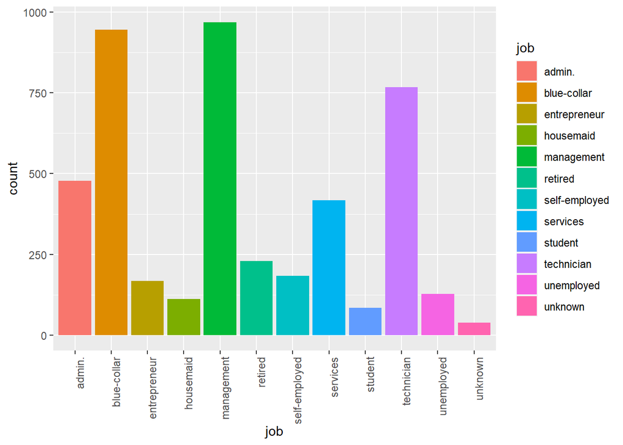

```r
ggplot(res, aes(job, count, fill=job))  +
  geom_bar(stat = 'identity', position = 'dodge') +
  theme(axis.text.x = element_text(angle=90, hjust=1))
```

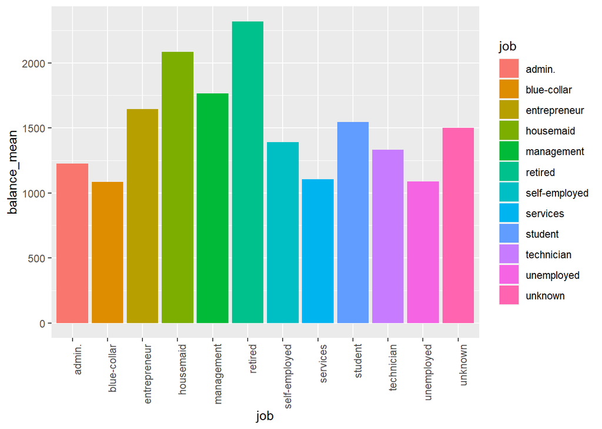

```r
ggplot(res, aes(job, balance_mean, fill=job))  +
  geom_bar(stat = 'identity', position = 'dodge') +
  theme(axis.text.x = element_text(angle=90, hjust=1))
```

# Finding #4

## Discover insights of education and job

- Primary education leads to most blue-collar jobs.
- Secondary education leads to most admin, blue-collar, services and technician jobs.
- Tertiary educaiton leads to most management jobs, and these prople contributed to the largest total balance.

```r
group_by(bank, education,job) %>%
  summarise(count = n(),
            balance_mean = mean(balance),
            balance_sum = sum(balance),
            default_count = sum(ifelse(default == "no", 0, 1)),
            subscription_count = sum(ifelse(y == "no", 0, 1)),
            "default_rate(%)" = default_count/count*100,
            "subscription_rate(%)" = subscription_count/count*100) %>%
  arrange(education) -> res
## `summarise()` regrouping output by 'education' (override with `.groups` argument)
res
```

```
## # A tibble: 48 x 9
## # Groups:   education [4]
##    education job   count balance_mean balance_sum default_count subscription_co~
##    <fct>     <fct> <int>        <dbl>       <int>         <dbl>            <dbl>
##  1 primary   admi~    17         391.        6640             0                1
##  2 primary   blue~   369        1072.      395647             4               16
##  3 primary   entr~    26         384.        9982             2                3
##  4 primary   hous~    57        1807.      103005             1                8
##  5 primary   mana~    39        2685.      104731             0                5
##  6 primary   reti~    80        2745.      219568             1               16
##  7 primary   self~    15        1472.       22076             0                2
##  8 primary   serv~    25        1107.       27683             1                3
##  9 primary   stud~     2        1788.        3575             0                2
## 10 primary   tech~    15        2593        38895             0                3
## # ... with 38 more rows, and 2 more variables: `default_rate(%)` <dbl>,
## #   `subscription_rate(%)` <dbl>
```

# Finding #5

## Discover insights of housing loan

- People with no housing loans tend to be elder, have more balance and double the subscription rate than those with housing loans

```r
group_by(bank, housing) %>%
  summarise(count = n(),
            balance_mean = mean(balance),
            age_mean = mean(age),
            default_count = sum(ifelse(default == "no", 0, 1)),
            subscription_count = sum(ifelse(y == "no", 0, 1)),
            "default_rate(%)" = default_count/count*100,
            "subscription_rate(%)" = subscription_count/count*100) %>%
  arrange(housing) -> res
## `summarise()` ungrouping output (override with `.groups` argument)
res
```

```
## # A tibble: 2 x 8
##   housing count balance_mean age_mean default_count subscription_co~
##   <fct>   <int>        <dbl>    <dbl>         <dbl>            <dbl>
## 1 no       1962        1595.     43.5            31              301
## 2 yes      2559        1290.     39.4            45              220
## # ... with 2 more variables: `default_rate(%)` <dbl>,
## #   `subscription_rate(%)` <dbl>
```

# Finding #6

## Discover insights of contact and type

- Contacts through teltphone tend to have shorter duration but almost same subscription rate as cellular contact and much higher than unknown contact

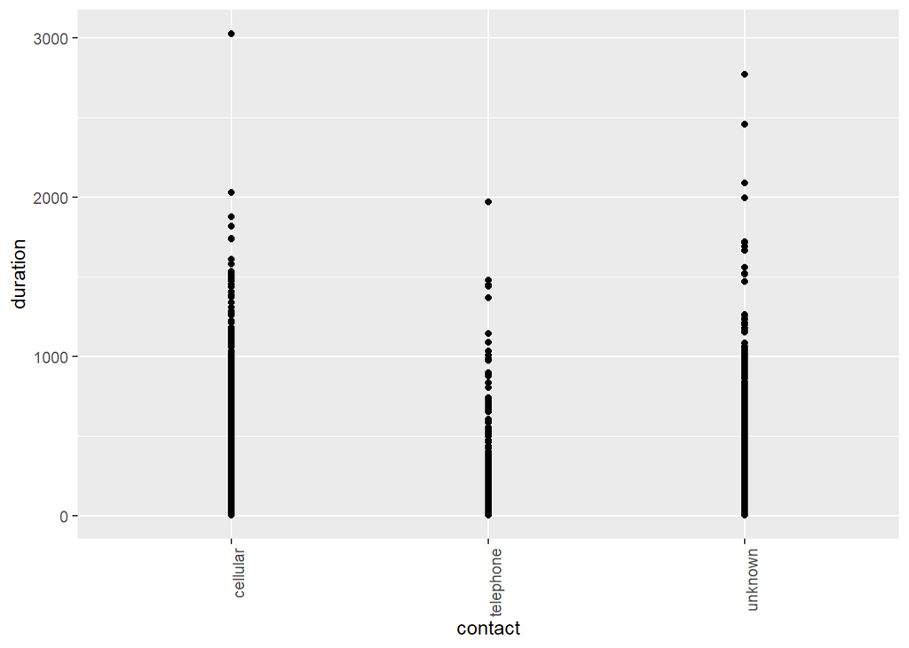

```r
ggplot(bank, aes(contact, duration)) +
  geom_point() +
  theme(axis.text.x = element_text(angle=90, hjust=1))
```

```r
group_by(bank, contact) %>%
  summarise(count = n(),
            balance_mean = mean(balance),
            duration_mean = mean(duration),
            default_count = sum(ifelse(default == "no", 0, 1)),
            subscription_count = sum(ifelse(y == "no", 0, 1)),
            "default_rate(%)" = default_count/count*100,
            "subscription_rate(%)" = subscription_count/count*100) %>%
  arrange(contact) -> res
## `summarise()` ungrouping output (override with `.groups` argument)
res
```

```
## # A tibble: 3 x 8
##   contact count balance_mean duration_mean default_count subscription_co~
##   <fct>   <int>        <dbl>         <dbl>         <dbl>            <dbl>
## 1 cellul~  2896        1423.          267.            48              416
## 2 teleph~   301        1806.          243.             2               44
## 3 unknown  1324        1334.          262.            26               61
## # ... with 2 more variables: `default_rate(%)` <dbl>,
## #   `subscription_rate(%)` <dbl>
```

# Finding #7

## Discover insights of last contact month

```r
bank %>%
  group_by(month,y) %>%
  summarise(count = n()) %>%
  arrange(month) -> res
## `summarise()` regrouping output by 'month' (override with `.groups` argument)
res
```

```
## # A tibble: 24 x 3
## # Groups:   month [12]
##    month y     count
##    <fct> <fct> <int>
##  1 apr   no      237
##  2 apr   yes      56
##  3 aug   no      554
##  4 aug   yes      79
##  5 dec   no       11
##  6 dec   yes       9
##  7 feb   no      184
##  8 feb   yes      38
##  9 jan   no      132
## 10 jan   yes      16
## # ... with 14 more rows
```

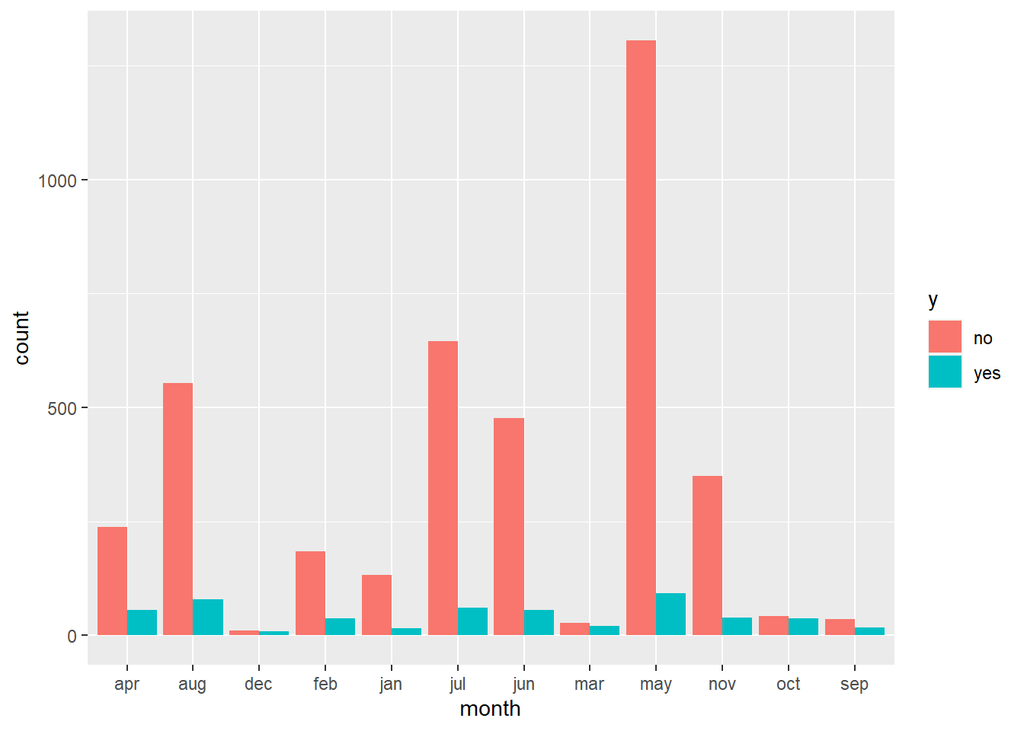

```r
ggplot(res, aes(month, count, fill=y)) +
  geom_bar(stat = 'identity', position = 'dodge')
```

```r
group_by(bank, month) %>%
  summarise(count = n(),
            subscription_count = sum(ifelse(y == "no", 0, 1)),
            "subscription_rate(%)" = round(subscription_count/count*100,2)) %>%
  arrange(month) -> res
## `summarise()` ungrouping output (override with `.groups` argument)
res
```

```
## # A tibble: 12 x 4
##    month count subscription_count `subscription_rate(%)`
##    <fct> <int>              <dbl>                  <dbl>
##  1 apr     293                 56                  19.1
##  2 aug     633                 79                  12.5
##  3 dec      20                  9                  45
##  4 feb     222                 38                  17.1
##  5 jan     148                 16                  10.8
##  6 jul     706                 61                   8.64
##  7 jun     531                 55                  10.4
##  8 mar      49                 21                  42.9
##  9 may    1398                 93                   6.65
## 10 nov     389                 39                  10.0
## 11 oct      80                 37                  46.2
## 12 sep      52                 17                  32.7
```

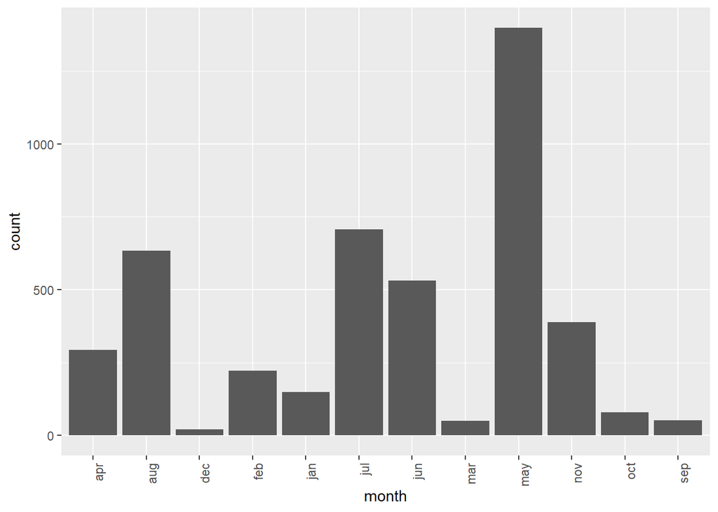

```r
ggplot(res, aes(month, count))  +
  geom_bar(stat = 'identity', position = 'dodge') +
  theme(axis.text.x = element_text(angle=90, hjust=1))
```